# Práctica 1: Metaheurísticas basadas en trayectorias: Temple Simulado

## Instrucciones

Esto es **Jupyter Notebook**, un documento que integra código Python en un archivo Markdown. Esto nos permite ir ejecutando celdas de código poco a poco, así como generar un informe bien formateado de la práctica.

Puedes añadir una celda con el botón **"Insert"** de la barra de herramentas, y cambiar su tipo con **"Cell > Cell Type"**

Para ejecutar una celda de código, la seleccionaremos y pulsaremos el botón **"▶ Run"** de la barra de herramentas. Para pasar el documento a HTML, seleccionaremos **"File > Download as > HTML (.html)"**

Sigue este guion hasta el final. Ejecuta el código proporcionado paso a paso comprendiendo lo que estás haciendo y reflexionando sobre los resultados. Habrá preguntas intercaladas a lo largo del guion. Responde a todas ellas en la sección reservada para ese fin: **"Respuestas a los ejercicios"**. Por favor, no modifiques ninguna línea de código excepto cuando se te pida explícitamente.

No olvides insertar tu **nombre y apellidos** en la celda superior.

## Entrega de la práctica

La fecha límite de entrega será la indicada en el Campus Virtual. La entrega consistirá de un único archivo comprimido con nombre `APELIDOS_NOME_TempleSimulado.zip` que contenga los siguientes ficheros:

- `APELIDOS_NOME_TempleSimulado.html`: Archivo HTML fruto de la exportación del presente Notebook, con las preguntas respondidas al final del documento.
- `APELIDOS_NOME_TempleSimulado.ipynb`: Archivo fuente Jupyter Notebook.
- Archivo de datos de los problemas utilizados en la resolución.

## Preliminares adicionales sobre Python para esta práctica

Conviene familiarizarse con algunas funciones disponibles en Python que pueden resultarte especialmente útiles más adelante en la realización de esta práctica.

Por ejemplo, puedes generar números aleatorios de la siguiente forma utilizando el paquete `random`.

```python
import random

# podemos crear un numero aleatorio entre 1 y 10
numero_aleatorio = random.randint(1, 10)
print(numero_aleatorio)

# y números aleatorios entre 0 y 1 siguiendo también una distribución uniforme
numero_U = random.uniform(0,1)
print (numero_U)
```

```
9
0.04740574703244205
```

Puedes generar vectores de números fijos y aleatorios que a su vez estén barajados de manera aleatoria como se ilustra a continuación.

```python
vector = [x for x in range (1,10)]
print ("vector fijo ", vector)

random.shuffle(vector)
print (vector)

vector_aleatorio = [ random.randint(1, 10) for i in range(1,10) ]
print ("vector aleatorio ", vector_aleatorio)

random.shuffle(vector_aleatorio)
print (vector_aleatorio)
```

```
vector fijo  [1, 2, 3, 4, 5, 6, 7, 8, 9]
[4, 7, 5, 6, 2, 1, 3, 9, 8]
vector aleatorio  [5, 8, 5, 8, 3, 1, 5, 4, 9]
[9, 5, 4, 5, 8, 3, 8, 1, 5]
```

Puedes incluso fijar la semilla para generar números aleatorios si quisieras que la aleatorización fuera determinista (i.e., secuencias de números aletorios que pueden ser reproducibles). Fíjate en el siguiente ejemplo que muestra como esta determina la secuencia de número si se establece una semilla y por tanto su repitibilidad. Esto puede ser útil si queremos asegurar que dos ejecuciones den el mismo resultado.

```python
import time

# este vector será aleatorio si no habíamos establecido una semilla previamente.
# Podríamos tener incluso una semilla basada en el tiempo actual para forzar que se aleatorice
# si ejecutamos esta celda múltiples veces
random.seed(time.time())

vector_aleatorio = [ random.randint(1, 10) for i in range(1,10) ]
print ("vector aleatorio ", vector_aleatorio)

# aquí establecemos una semilla totalmente fija
# que no depende del tiempo y por tanto está bajo nuestro control
semilla = 123456
random.seed (semilla)

# este viene determinado por la semilla
vector_aleatorio = [ random.randint(1, 10) for i in range(1,10) ]
print ("vector aleatorio ", vector_aleatorio)

# y ahora somos capaces de generar la misma serie "aleatoria"
random.seed (semilla)
vector_aleatorio = [ random.randint(1, 10) for i in range(1,10) ]
print ("vector aleatorio igual que el anterior", vector_aleatorio)
```

```
vector aleatorio  [7, 6, 6, 6, 1, 6, 8, 4, 3]
vector aleatorio  [5, 1, 3, 1, 2, 1, 5, 1, 2]
vector aleatorio igual que el anterior [5, 1, 3, 1, 2, 1, 5, 1, 2]
```

Un último ejemplo del uso de la semilla sería establecerla justo antes de invocar a una función que queremos hacer la aleatorización totalmente determinista por cuestiones reproducibilidad. Puedes averiguar más en: https://docs.python.org/3/library/random.html

```python
def mi_funcion_pseudo_aleatoria (semilla=None):
    # también podemos recibir la semilla y establecerla en la primera línea
    if (semilla is not None):
        random.seed(semilla)

    mi_vector_aleatorio = [ random.randint(1, 10) for i in range(1,10) ]
    return mi_vector_aleatorio


random.seed(12345)
vector_aleatorio = mi_funcion_pseudo_aleatoria()
print ("vector aleatorio ", vector_aleatorio)

random.seed(54321)
vector_aleatorio = mi_funcion_pseudo_aleatoria()
print ("vector aleatorio ", vector_aleatorio)

random.seed(12345)
vector_aleatorio = mi_funcion_pseudo_aleatoria()
print ("vector aleatorio ", vector_aleatorio)


vector_aleatorio = mi_funcion_pseudo_aleatoria(12345)
print ("vector aleatorio ", vector_aleatorio)
```

```
vector aleatorio  [7, 1, 5, 6, 4, 5, 10, 7, 3]
vector aleatorio  [8, 2, 4, 3, 9, 9, 7, 3, 6]
vector aleatorio  [7, 1, 5, 6, 4, 5, 10, 7, 3]
vector aleatorio  [7, 1, 5, 6, 4, 5, 10, 7, 3]
```

Otro conjunto de funciones importantes son las que vienen del módulo `math`. Puedes encontrar una lista de las funciones disponibles en https://docs.python.org/3/library/math.html. Ponemos a continuación algunos ejemplos de uso.

```python
import math

# número e elevado a la potencia indicada
e=math.exp(1)
print (e)

power2_e=math.exp(2)
print (power2_e)

# ejemplo de potencia
print(math.pow(e, 1))
print(math.pow(e, 2))

# ejemplo del logaritmo natural de base e
base = e
print (math.log(e))
print (math.log(e, base))
```

```
2.718281828459045
7.38905609893065
2.718281828459045
7.3890560989306495
1.0
1.0
```

Finalmente, las funciones del módulo `time` te permiten obtener de manera aproximada tiempos de ejecución de secciones concretas de código.

```python
import time
start_time = time.time()

sum = 0
for i in range(1000000):
    sum = sum * 1

print("---- %s segundos ----" % (time.time() - start_time))
```

```
---- 0.15739107131958008 segundos ----
```

## El Problema del Viajante de Comercio (VC) con Temple Simulado

El objetivo de esta práctica es modelar e implementar un agente inteligente que sea capaz de resolver el problema del VC mediante la metaheurística (MH) de Enfriamiento o Temple Simulado (SA, del inglés Simulated Annealing). Para ello, realizarás una implementación del algoritmo básico visto en la clase expositiva y valorarás si la introducción de modificaciones en el diseño del algoritmo te permite mejorar la calidad de las soluciones alcanzadas.

### Definición del problema de Viajante de Comercio (VC)

El problema del viajante de comercio (VC) es el problema de la persona que quiere vender un producto, y que para ello quiere encontrar el viaje más corto posible a través de las ciudades de los clientes, haciendo una única visita a cada una, empezando y acabando el recorrido en su propia ciudad (recorrido circular desde la ciudad inicial).

Típicamente, el problema parte de una representación mediante un grafo ponderado G=(N, A), donde N es el conjunto de n=|N| nodos (ciudades), y siendo A el conjunto de arcos conectando los nodos. Cada arco (i, j) ∈ A tiene asignado un peso d_ij que representa la distancia entre las ciudades i y j.

Para facilitar vuestra labor de implementación, os proporcionamos la clase `Localizaciones`, que permite cargar las localizaciones GPS que representan los vértices del grafo G de N ciudades, y permite calcular de manera transparente la distancia entre cualquier par de ciudades usando la fórmula del semiverseno https://es.wikipedia.org/wiki/F%C3%B3rmula_del_semiverseno, que sirve para calcular las distancias teniendo en cuenta la curvatura de la Tierra.

En primer lugar deberás importar el módulo Python que acompaña esta práctica, que trae alguna función de apoyo implementada así como la clase de carga de datos.

```python
from helpers_mod_sa import *
```

Inspecciona el código de carga de localizaciones mediante `psource(Localizaciones)`

```python
psource (Localizaciones)
```

```
class Localizaciones ():

    def __init__ (self, filename='./data/grafo8cidades.txt'):
        self.filename = filename
        file = open(filename, 'r')
        Lines = file.readlines()

        count = -1
        self.nciudades = 0
        self.tablaciudades = dict()
        for line in Lines:
            if count == -1:
                self.nciudades = int(line.strip().split()[0])
            else:
                tokens = line.strip().split()
                self.tablaciudades[count]=tuple((float(tokens[0]),float(tokens[1])))

            count+=1

        self.matriz = []
        for c1 in range(self.nciudades):
            a = [0]*self.nciudades
            self.matriz.append(a)
            for c2 in range(self.nciudades):
                self.matriz[c1][c2] = self.__distancia_semiverseno__(c1, c2)

    def __distancia_semiverseno__ (self, c1, c2):
        radioTierra = 6371
        lat1 = math.radians(self.tablaciudades[c1][0]);
        lon1 = math.radians(self.tablaciudades[c1][1]);
        lat2 = math.radians(self.tablaciudades[c2][0]);
        lon2 = math.radians(self.tablaciudades[c2][1]);

        sinChi = math.sin((lat2 - lat1) / 2);
        sinLambda = math.sin((lon2 - lon1) / 2);

        raiz = (sinChi * sinChi) + math.cos(lat1) * math.cos(lat2) * (sinLambda * sinLambda);

        return 2 * radioTierra * math.asin(math.sqrt(raiz));

    def distancia (self, c1, c2):
        return self.matriz [c1][c2]
```

Fíjate que por defecto se carga el fichero `./data/grafo8cidades.txt`, que contiene las coordenadas GPS de 8 ciudades gallegas, siendo Santiago de Compostela la primera de ellas. La primera línea de estos ficheros indica el número de ciudades n, mientras que cada una de las líneas sucesivas especifican las coordenadas de cada ciudad, especificadas como coordenadas GPS (latitud y longitud en grados).

Puedes cargar otro fichero haciendo uso del parámetro `filename` como se muestra a continuación. Si todo va bien, la primera distancia entre la ciudad 0 y 1 debe ser unos 55 km.

```python
g1=Localizaciones(filename='./data/grafo8cidades.txt')
print (g1.distancia(0,1))
g2=Localizaciones(filename='./data/grafos10_10/grafo_1.txt')
print (g2.distancia(0,1))
```

```
55.88273580792048
119.30959564041359
```

El VC se reduce al problema de crear el circuito Hamiltoniano de longitud mínima sobre el grafo G. La solución a una instancia del problema del VC puede representarse como una permutación de los índices de las ciudades, donde lo importante es el orden de visita, que determinará el coste del viaje en términos de la distancia recorrida total.

El problema pertenece a la categoría de problemas NP, ya que el espacio de búsqueda posible está formado por todas las permutaciones de las n ciudades. Esto hace que resolver instancias de problemas con muchas ciudades (n grande) haga el problema impracticable con estrategias de búsqueda no-informadas y éste pueda beneficiarse de ciertas metaheurísticas (MH), pudiendo abordar de problemas con tallas más grande a la vez que se obtienen soluciones razonablemente buenas. En esta primera práctica, te vas a centrar en implementar y estudiar la MH Enfriamiento o Temple Simulado.

## P1.1: Implementación básica de Temple Simulado

Implementa el algoritmo básico de Temple Simulado para resolver el problema del VC enunciado arriba. Para ello, revisa la descripción algorítmica de la MH vista en la clase expositiva (Véase T1, diapositiva 40 y asociadas).

Ten en cuenta las siguientes consideraciones de diseño para completar la implementación básica:

- Representación de las soluciones: representación de orden (permutaciones) comenzando y finalizando en la ciudad 0.
- Solución inicial: generación aleatoria de una permutación válida.
- Operador de selección de la solución siguiente Scand a partir de la actual Sact: operador de intercambio.
- Velocidad de enfriamiento: se ha generado un único vecino.
- Función de coste: suma de las distancias del camino según el orden del recorrido.
- Mecanismo de enfriamiento: mecanismo exponencial decreciente que sigue la expressión 𝑇(𝑘)=T0·𝑒(−𝜆𝑘), donde 𝑘 es el número de iteración y T0, λ son los parámetros de diseño.

  Para esta implementación básica considera, 𝑇(𝑘) = 20 · 𝑒(−0.0045𝑘), para establecer los parámetros por defecto de T0 y 𝜆, con temperatura inicial fija T0=20 y 𝜆=0.0045 respectivamente.
- Condición de parada: número fijo de iteraciones (limite=1000). No se precisa definir Tfinal.

Para verificar tu implementación, puedes utilizar el fichero de localizaciones de 8 ciudades gallegas (*grafo8cidades.txt*). La solución óptima resuelta con una búsqueda informada como A* se sitúa en torno a los 382km.

Para comprobar que tu implementación es suficientemente general como para manejar problemas del VC diferentes tallas, puedes probar también con el fichero de localizaciones de 120 ciudades de USA proporcionado en esta práctica (*US120.txt*).

**IMPORTANTE**: Es imprescindible que en tu implementación tengas funciones totalmente parametrizadas para el mecanismo de enfriamiento y la función de coste; también deberías parametrizar el algoritmo para poder recibir una solución inicial y una semilla para inicializar el generador de números aleatorios al principio de la ejecución del algoritmo de Temple Simulado. Estas recomendaciones sobre modularidad te facilitará la resolución de las cuestiones del test automático de evaluación.

```python
import matplotlib.pyplot as plt
#funcion de representacion de las soluciones
def representacion_soluciones(localizaciones,solucion):
    #utilizamos los datos que ya nos da localizaciones
    latitudes = [coord[0] for coord in localizaciones.tablaciudades.values()]
    longitudes = [coord[1] for coord in localizaciones.tablaciudades.values()]

    plt.scatter(longitudes, latitudes, c='blue')
   # Dibujamos las líneas entre las ciudades en el orden de la solución
    for i in range(len(solucion) - 1):
        ciudad1 = solucion[i]
        ciudad2 = solucion[i + 1]
        latitudes = [localizaciones.tablaciudades[ciudad1][0], localizaciones.tablaciudades[ciudad2][0]]
        longitudes = [localizaciones.tablaciudades[ciudad1][1], localizaciones.tablaciudades[ciudad2][1]]
        plt.plot(longitudes, latitudes, c='red', linewidth=1)

    plt.show()
```

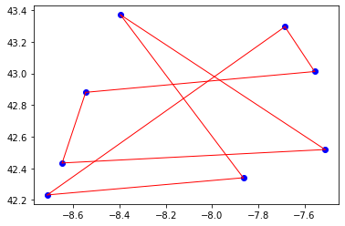

```python
representacion_soluciones(g1,scand)
```

```python
# Como se debe empezar y acabar en la misma ciudad 0,
# utilizamos un vector con el orden de las ciudades en el cual la ciudad 0 sea la primera y la ultima.
# ciudades=[0,1,2,3,4,5,6,7,0] ->mecanismo de enfriamento cada 10 iteraciones

# primero creamos la solucion inicial que necesita como parametro el numero de locaciones
def solucion_inicial(locaciones):
    sol = [x for x in range(1,locaciones.nciudades)]
    random.shuffle(sol)
    return [0]+sol+[0] #añadimos la primera ciudad que será el punto de partida y el punto final
```

```python
#Operador de selección de la solución siguiente Scand a partir de la actual Sact: operador de intercambio.
def operador_intercambio(locaciones, sact):
    #escogemos de forma aleatoria dos locaciones para intercambiar
    loc1 = random.randint(1,locaciones.nciudades-1)#menos 1 o menos 2
    loc2 = random.randint(1,locaciones.nciudades-1)
    while loc1==loc2:
        loc2 = random.randint(1,locaciones.nciudades-1)

    #sact[loc1],sact[loc2] = sact[loc2],sact[loc1]
    scand = sact.copy()
    scand[loc1], scand[loc2]=sact[loc2],sact[loc1]
    return scand
```

```python
sact=solucion_inicial(g1)
print(sact)
scand = operador_intercambio(g1,sact)
print(scand)
```

```
[0, 3, 2, 6, 5, 1, 7, 4, 0]
[0, 3, 2, 6, 5, 1, 4, 7, 0]
```

```python
#funcion de coste
def coste(locaciones,sol):
    suma = 0
    for i in range(0, len(sol)-1):
        suma+= locaciones.distancia(sol[i], sol[i+1])
    return suma
```

```python
#mecanismo de enfriamiento 𝑇(𝑘) = 20 · 𝑒(−0.0045𝑘)
t0 = 20
y = 0.0045

def enfriamiento(k,t0):
    T = t0*math.pow(e, -0.0045*k)
    return T
```

```python
#temple simulado

def temple_simulado(locaciones,T0, limite ):
    sact = solucion_inicial(locaciones)
    #guardamos la solucion por si es la mejor
    sol = sact
    #tiempo inicial
    t = enfriamiento(0,T0)
    x=0
    #hacemos que el limite se pueda cambiar facilmente para hacer pruebas
    while (x<limite):
        scand = operador_intercambio(locaciones,sact)
        cost = coste(locaciones, scand) - coste(locaciones, sact) #diferencia de coste entra soluciones
        if cost<0:
            sact = scand
            sol = sact.copy()
        else:
            if random.uniform(0,1)< math.exp(-cost / t):
                sact = scand #aceptamos
        x=x+1;
        t = enfriamiento(x,T0)#enfriamos

    return sol
```

```python
solucion = temple_simulado(g1,20,1000)
print(solucion, coste(g1,solucion))

g120 = Localizaciones(filename='./data/US120.txt')
sol = temple_simulado(g120,20,1000)
print(sol, coste(g120,sol))
```

```
[0, 1, 2, 3, 4, 5, 6, 7, 0] 381.6699617675482
[0, 43, 66, 46, 95, 54, 51, 8, 71, 86, 104, 33, 39, 15, 23, 17, 52, 117, 99, 61, 106, 32, 109, 68, 10, 72, 20, 63, 113, 110, 2, 38, 98, 9, 92, 27, 65, 70, 60, 41, 93, 28, 37, 89, 82, 105, 87, 76, 44, 45, 30, 6, 77, 69, 31, 96, 73, 88, 67, 12, 1, 5, 108, 85, 19, 14, 11, 58, 84, 78, 79, 80, 111, 116, …
```

❓ **Pregunta 1**. Explica brevemente los detalles relevantes de tu código para entender tu implementación (p.ej., estructura de tu código, funciones, etc.)

**Repuesta 1:** La implementación básica se hace modularmente para que sea más fácil posteriormente el cambio de datos. Para eso tenemos las funciones de representación de soluciones, creación aleatoria de la solución inicial, la funcion que permuta dos localizaciones en la solucion principal, el coste, el enfriamiento y por ultimo el propio algoritmo de temple simulado que utiliza las funciones anteriores.

❓ **Pregunta 2**. ¿Siempre obtienes soluciones óptimas en cada problema? ¿En qué proporción? Muestra cómo has realizado la verificación y explica brevemente los resultados obtenidos.

Notas: sé conservador en tu estrategia para verificar tu implementación, especialmente cuando empleas ficheros de datos grandes como el del problema de las ciudades USA. Si dejas ejecutando tu algoritmo por un número elevado de iteraciones, puede resultarte útil medir el tiempo que tarda para tomar decisiones sobre donde establecer el límite.

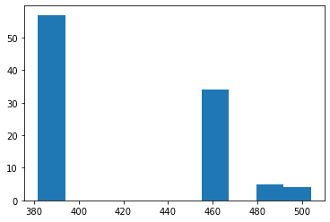

```python
def proporcion(locaciones, numRepeticiones):
    resultado = [coste(locaciones, temple_simulado(locaciones,20,1000)) for x in range(0, numRepeticiones)]
    plt.hist(resultado)

proporcion(g1,100)
```

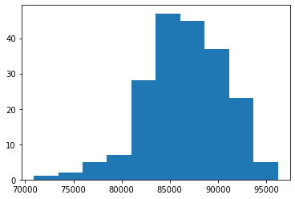

```python
proporcion(g120,200)
```

### Ajuste dinámico de temperatura inicial

En tu implementación has establecido la temperatura inicial siguiendo un valor fijo completamente arbitrario. Esto puede no resultar siempre adecuado, y suele ser más conveniente disponer de un ajuste de la temperatura inicial (T0) que tenga en cuenta la instancia del problema a resolver.

Modifica la implementación anterior para que puedas parametrizar el valor inicial del parámetro de control T0 utilizando la siguiente fórmula:

```
𝑇0 = (−𝜇/ln(𝜙))·𝐶(𝑆0), que permite aceptar (con una probabilidad 𝜙) soluciones siguientes que empeoren en μ (tanto por uno) a S0 (esto es, que sean (1+ μ) veces peores).
```

En la fórmula, C(S0) es el coste de la solución inicial, con valores por defecto 𝜙=0.50 y 𝜇=0.01.

```python
# puedes añadir aquí la implementación o cualquier código que necesites, teniendo múltiples celdas,
# o puedes modificar el de arriba, respetando siempre que sea posible establecer
# TO de manera fija  o mediante un Phi y Mu dados
def temp(coste, phi = 0.5, mu = 0.01):
    return (-mu/math.log(phi))*coste

y = 0.0045
phi = 0.5
mu = 0.01
def temple_simulado_2(locaciones, limite, y, phi, mu):
    sact = solucion_inicial(locaciones)
    sol = sact
    t0 = temp(coste(locaciones, sact), phi, mu)
    t = t0
    x = 0
    while (x<limite):
        scand = operador_intercambio(locaciones,sact)
        cost = coste(locaciones, scand) - coste(locaciones, sact) #diferencia de coste entra soluciones
        if cost<0:
            sact = scand
            sol = sact.copy()
        else:
            if random.uniform(0,1)< math.exp(-cost / t):
                sact = scand #aceptamos
        x=x+1;
        t = enfriamiento(x,t0)#enfriamos

    return sol
```

```python
solucion = temple_simulado_2(g1,1000, 0.0045,0.5,0.01)
print(solucion, coste(g1,solucion))

sol = temple_simulado_2(g120,1000, 0.0045,0.5,0.01)
print(sol, coste(g120,sol))
```

```
[0, 1, 2, 3, 4, 5, 6, 7, 0] 381.6699617675482
[0, 119, 83, 4, 44, 6, 85, 20, 112, 5, 111, 88, 96, 104, 95, 12, 60, 63, 3, 9, 28, 71, 10, 89, 37, 42, 47, 75, 117, 23, 49, 72, 31, 46, 1, 18, 50, 36, 35, 94, 52, 17, 103, 25, 70, 87, 33, 15, 67, 116, 29, 32, 78, 114, 66, 56, 115, 106, 118, 54, 108, 93, 38, 40, 113, 110, 53, 65, 34, 2, 58, 27, 99, 6…
```

❓ **Pregunta 3.1**. Confecciona una tabla que muestre la relación de 𝐶(𝑆0), 𝜙 y 𝜇 con T0 para los dos problemas utilizados anteriormente (ciudades gallegas y ciudades USA). Entonces, amplia de manera razonada la tabla con variaciones de 𝜙 y 𝜇 para cada uno de los problemas. ¿Qué combinación de 𝜙 y 𝜇 da mayor/menor T0?

```python
import pandas as pd
#Variaciones para cada problema
phis = [0.1,0.2,0.5,0.8,0.6,0.8]
mus = [0.01,0.02,0.05,0.08,0.1,0.2]

def tabla_dataframe(locaciones):
    sact = solucion_inicial(locaciones)
    array_phis=[]
    for phi in phis:
        array_mus=[]
        for mu in mus:
            #calculamos la T0 para cada combinacion
            array_mus.append(temp(coste(locaciones, sact),phi,mu))
        array_phis.append(array_mus)
    return pd.DataFrame(array_phis, columns=[str(p) for p in phis], index=[str(m) for m in mus])
```

```python
tabla_dataframe(g1)
```

[output not shown]

```python
tabla_dataframe(g120)
```

[output not shown]

**Respuesta 3.1:** ¿Qué combinación de 𝜙 y 𝜇 da mayor/menor T0? En las tablas podemos ver como se obtiene un menor T0 en ambos casos g1 y g120 cuando se obtienen unos valores menores de phi y mu, en este caso los menores valores que probamos son 0.1 y 0.01 respectivamente. Los valores más altos de T0 los encontramos con los valores más altos de phi y de mu. Tambien se puede ver como se produce un mayor incremento mientras incrementan las phis.

❓ **Pregunta 3.2**. Escoge 4 combinaciones variadas de parámetros (incluidos los que regulan el mecanismo de enfriamiento, e.g., 𝜆). Ejecuta el algoritmo de Temple Simulado con esas combinaciones. Guarda los resultados en una celda, y discute los resultados obtenidos en cuanto a la calidad de las soluciones obtenidas.

**Respuesta 3.2:** Probamos las combinaciones con el grafo de las ciudades de USA puesto que con las gallegas no se ve mucha diferencia. Como dijimos antes, con la combinacion [0.1,0.01] es con la que mejores resultados encontramos mientras que los peores los encontramos con la combinacion con valores mas altos [0.4,0.09]. Aunque en proporcion, viendo la cantidad de veces que se llego a cada resultado, en la segunda gráfica se puede ver como la mayor parte de los resultados se agrupan en un rango más pequeño que en otras gráficas.

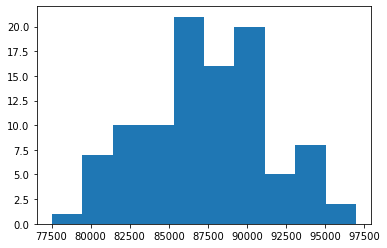

```python
#[[0.1,0.01],[0.5,0.01],[0.1,0.08],[0.4,0.09]]
def proporcion2(locaciones, numRepeticiones,y, phi,mu):
    resultado = [coste(locaciones, temple_simulado_2(locaciones,1000,y,phi,mu)) for x in range(0, numRepeticiones)]
    plt.hist(resultado)

proporcion2(g120,100,0.045,0.1,0.01)
```

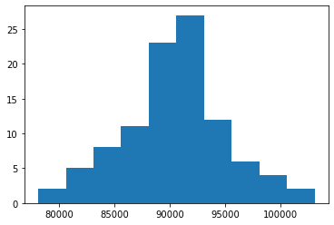

```python
proporcion2(g120,100,0.045,0.5,0.01)
```

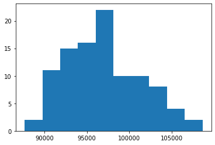

```python
proporcion2(g120,100,0.045,0.1,0.08)
```

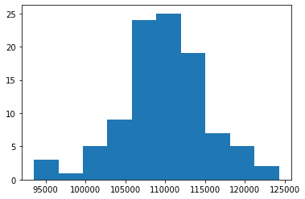

```python
proporcion2(g120,100,0.045,0.4,0.09)
```

## P1.2: Mejoras del algoritmo de Temple Simulado

En esta sección el objetivo es realizar mejoras al algoritmo desarrollado previamente, de acuerdo con lo visto en las clases expositivas. Podrá modificarse cualquiera de los siguientes parámetros u operadores:

- El valor inicial del parámetro de control (T0).
- El mecanismo de enfriamiento.
- La velocidad de enfriamiento.
- El mecanismo de selección de las soluciones candidatas
- El criterio de parada

**Importante**: Debes mantener una implementación de la versión básica que pueda ser ejecutada en la evaluación. Así que se recomienda que la implementación del algoritmo con las mejoras sea implementada en otra función reservada para la versión mejorada.

❓ **Pregunta 4**. Implementa un laboratorio para evaluar el impacto de las mejoras consideradas. ¿Qué intervenciones de mejora te ha llevado a mejores resultados? ¿Cuáles no parecen haber funcionado tan bien como esperabas y por qué? Explica brevemente las mejoras o intervenciones de mejora realizadas, cómo la has implementado, porqué las consideras buenas o no para el problema y presenta tus conclusiones acompañadas de los resultados obtenidos.

**Importante**: Aunque puedes obtener tantas celdas de ejecución de laboratorio y resultados como necesites, tu informe final en respuestas a la pregunta 4 no debería superar las 1200 palabras.

**Respuesta 4:** Han sido mejoras el cambio de criterio de parada y la búsqueda exhaustiva del entorno. En cambio el enfriamiento de Boltzmann no lo considero como mejora puesto que es prácticamente igual a las soluciones de la implementación normal de temple simulado.

```python
#mejora criterio de parada -> en vez de usar el limite 1000,
#buscamos parar cuando llevamos un numero de iteraciones sin mejorar.
def temple_con_parada(locaciones, T0, numIteracionesSinMejora):
    sact = solucion_inicial(locaciones)
    sol = sact
    t = enfriamiento(0,T0)
    x=0
    iteraciones=0 #numero de iteraciones que van sin mejorar
    while iteraciones<numIteracionesSinMejora :
        scand = operador_intercambio(locaciones,sact)
        cost = coste(locaciones, scand) - coste(locaciones, sact)  # Diferencia de coste entre soluciones
        if cost<0:
            sact = scand
            sol = sact.copy()
            iteraciones = 0 #hubo mejora asi que reiniciamos el contador
        else:
            if random.uniform(0, 1) < math.exp(-cost / t):
                sact = scand
        x+=1
        t = enfriamiento(x, T0)
        iteraciones +=1
    return sol

def proporcion3(locaciones, numRepeticiones):
    resultado = [coste(locaciones, temple_con_parada(locaciones,20,500)) for x in range(0, numRepeticiones)]
    plt.hist(resultado)
```

```python
sol = temple_con_parada(g120, 20,300)
print(coste(g120,sol))
```

```
53638.08189202507
```

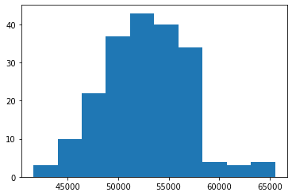

```python
proporcion3(g120,200)
```

[output not shown]

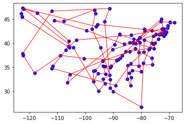

```python
sol2 = temple_con_parada(g120, 20,500)
print(sol, coste(g120,sol2))
representacion_soluciones(g120,sol2)
```

```
[0, 2, 110, 113, 14, 11, 63, 24, 23, 17, 103, 88, 73, 70, 12, 56, 66, 3, 28, 7, 104, 46, 96, 25, 53, 50, 55, 62, 21, 20, 87, 102, 44, 45, 76, 39, 1, 43, 32, 77, 114, 107, 22, 68, 100, 90, 38, 97, 57, 6, 30, 29, 116, 118, 15, 111, 9, 19, 67, 115, 106, 61, 94, 40, 8, 119, 81, 91, 51, 101, 10, 79, 89, …
```

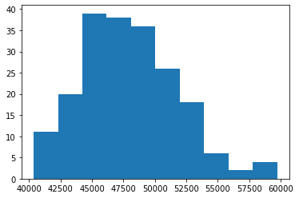

```python
#buscar vecino a ver si hay alguno mejor, busqueda mas exhaustiva del entorno
def temple_mejor_velocidad(locaciones, numVecinos):
    sact = solucion_inicial(locaciones)
    sol = sact
    t = enfriamiento(0,20)
    limite = 1000
    for i in range (0,limite):
        vecinos = 0
        mejoras = 0 #si encontramos un vecino mejor
        while vecinos< numVecinos and mejoras< 1:
            scand = operador_intercambio(locaciones,sact)
            vecinos +=1
            cost = coste(locaciones, scand) - coste(locaciones, sact)
            if cost<0:
                sact = scand
                sol = sact.copy()
            else:
                if random.uniform(0, 1) < math.exp(-cost / t):
                    sact = scand
                    mejoras+=1
        t = enfriamiento(i, 20)
    return sol

def proporcion4(locaciones, numRepeticiones):
    resultado = [coste(locaciones, temple_mejor_velocidad(locaciones,20)) for x in range(0, numRepeticiones)]
    plt.hist(resultado)

sol = temple_mejor_velocidad(g120,20)
print(sol, coste(g120,sol))
proporcion4(g120,200)
```

```
[0, 43, 32, 79, 80, 10, 101, 51, 89, 27, 34, 25, 49, 111, 70, 31, 102, 44, 30, 45, 6, 39, 116, 54, 112, 95, 72, 5, 15, 106, 115, 1, 90, 100, 68, 22, 91, 82, 105, 35, 7, 56, 40, 8, 107, 114, 81, 63, 41, 23, 117, 92, 60, 47, 86, 65, 93, 21, 55, 3, 28, 53, 4, 16, 9, 20, 73, 46, 104, 108, 33, 85, 118, 6…
```

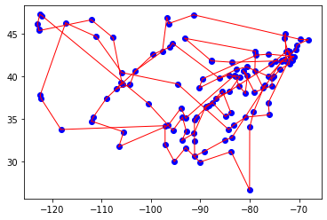

```python
sol = temple_mejor_velocidad(g120,20)
print(sol, coste(g120,sol))
representacion_soluciones(g120,sol)
```

```python
def temple_mejor_velocidad_con_parada(locaciones, numVecinos,numIteracionesSinMejora):
    sact = solucion_inicial(locaciones)
    sol = sact
    T0 =20
    t = enfriamiento(0,T0)
    limite = 1000
    iteraciones=0
    x=0
    while iteraciones<numIteracionesSinMejora :
        vecinos = 0
        mejoras = 0 #si encontramos un vecino mejor
        while vecinos< numVecinos and mejoras< 1:
            scand = operador_intercambio(locaciones,sact)
            vecinos +=1
            cost = coste(locaciones, scand) - coste(locaciones, sact)
            if cost<0:
                sact = scand
                sol = sact.copy()
                iteraciones=0
            else:
                if random.uniform(0, 1) < math.exp(-cost / t):
                    sact = scand
                    mejoras+=1
        x=x+1
        t = enfriamiento(x, 20)
        iteraciones +=1

    return sol

def proporcion6(locaciones, numRepeticiones):
    resultado = [coste(locaciones, temple_mejor_velocidad_con_parada(locaciones,20,200)) for x in range(0, numRepeticiones)]
    plt.hist(resultado)
```

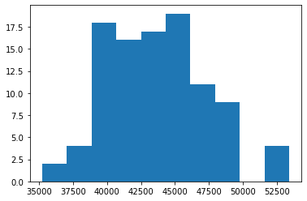

```python
proporcion6(g120,100)
```

```python
#enfriamiento de boltzmann
import math
def temple_simulado_boltzmann(locaciones,T0, limite ):
    sact = solucion_inicial(locaciones)
    #guardamos la solucion por si es la mejor
    sol = sact
    #tiempo inicial
    t0 = enfriamiento(0,T0)
    t = t0
    x=0
    #hacemos que el limite se pueda cambiar facilmente para hacer pruebas
    while (x<limite):
        scand = operador_intercambio(locaciones,sact)
        cost = coste(locaciones, scand) - coste(locaciones, sact) #diferencia de coste entra soluciones
        if cost<0:
            sact = scand
            sol = sact.copy()
        else:
            if random.uniform(0,1)< math.exp(-cost / t):
                sact = scand #aceptamos
        x=x+1;
        t = t0/math.log(1+x)#enfriamos

    return sol
```

```python
sol = temple_simulado_boltzmann(g120,20,1000)
print(coste(g120,sol))
```

```
86405.7918207312
```

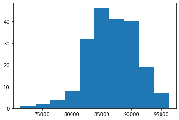

```python
def proporcion7(locaciones, numRepeticiones):
    resultado = [coste(locaciones,temple_simulado_boltzmann(g120,20,1000)) for x in range(0, numRepeticiones)]
    plt.hist(resultado)

proporcion7(g120,200)
```

#### Respuestas a los ejercicios (10 puntos)

Recordatorio: No olvides escribir tu nombre y apellidos en la segunda celda de este documento. Las respuestas a las preguntas deben venir acompañadas de las implementaciones necesarias para su respuesta, organizadas en celdas de tal forma que sea un documento fácil de leer y seguir.

*P1.1: Implementación básica* (5 puntos)

La implementación básica se evaluará mediante un cuestionario automático de evaluación. Este lo realizarás en la primera sesión de la próxima práctica, y se centrará en la resolución por tu parte de diversas cuestiones prácticas relacionadas con la implementación realizada, pudiendo ser necesaria la ejecución, adaptación y modificación de la misma.

Aclaración: Independientemente del cuestionario automático de evaluación, siempre considera que las preguntas planteadas en el notebook deben ser respondidas también. Esas preguntas generales están diseñadas para formarte, y te servián para razonar y reflexionar sobre el tema, así como también para fomentar una discusión constructiva con los docentes en caso de dudas.

*P1.2: Implementación mejoras* (5 puntos)

Pregunta 4 (MAX. 1200 palabras)

La evaluación de esta parte se llevará a cabo en términos de la completitud y correctitud del laboratorio implementado, y la calidad del propio informe, que debe ser conciso y preciso, pudiendo acompañarse de gráficas y tablas que faciliten y fundamenten la explicación e argumentación. Es muy importante explicar de manera clara, precisa y fundamentada. Se valorará más positivamente las intervenciones de mejora que tengan mayor dificultad de implementación que las triviales. Se reservará hasta un punto que se asignará en términos de la calidad de la mejor solución obtenida entre el conjunto de las prácticas entregadas (es por ello que no debes olvidar marcar en tu informe muy claramente cuál ha sido tu mejor solución y con qué configuración/versión).

# LABORATORIO

Para mejorar el rendimiento del algoritmo de Temple Simulado, hemos implementado tres variantes: una que modifica el criterio de parada, otra que explora de forma más exhaustiva el entorno y el enfriamiento de Boltzmann.

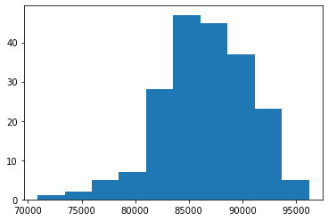

Método base

### Criterio de parada mejorado

El criterio de parada en el Temple Simulado es fundamental para determinar cuándo detener el algoritmo. En el enfoque base, se establece un límite fijo de iteraciones, lo que puede no ser óptimo para todas las instancias. En lugar de ejecutar un número fijo de iteraciones, el algoritmo mejorado puede detenerse más temprano si converge a una solución de calidad antes de alcanzar el límite máximo de iteraciones.

El criterio que utilizamos como criterio de parada es el número de iteraciones seguidas que se producen sin tener una mejora en la solución. Esto permite que se ejecute una exploración más intensiva cuando se encuentra una solución prometedora y una exploración más rápida cuando las soluciones actuales no están mejorando.

Para implementar esta mejora añadimos un parámetro que sea el número de iteraciones seguidas que son el criterio de parada y un contador que se va incrementando cuando la solución nueva no es mejor que la anterior y que se reinicia si se encuentra una solución mejor.

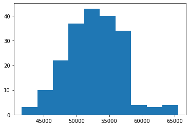

Método de parada mejorado

### Búsqueda exhaustiva del entorno

La búsqueda exhaustiva de soluciones vecinas implica explorar a fondo las posibles soluciones cercanas a la solución actual antes de pasar a la siguiente iteración. Esta mejora influye en la calidad de las soluciones encontradas ya que no solo depende de la probabilidad para aceptar o rechazar una solución. Así, no se pierden soluciones prometedoras simplemente debido a probabilidades aleatorias. De esta forma también se reduce el riesgo de quedar atrapado en óptimos locales.

Implementando esta mejora sobre el grafo de ciudades de USA obtenemos una mejora de 87k en el temple simulado base a 45-50k utilizando esta nueva implementación.

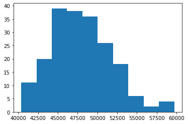

Método búsqueda del entorno

### Enfriamiento de Boltzmann

El método de Boltzmann es una estrategia de enfriamiento que permite una reducción gradual de la temperatura a lo largo de las iteraciones. Esta variante puede ser útil en problemas donde se desea una exploración inicial intensiva del espacio de soluciones, seguida de una explotación más detallada a medida que avanza el algoritmo. Para implementar este método solo es necesaria cambiar la función de enfriamiento y cambiar por el del método de Boltzmann, t=T0/math.log(1+x), siendo x la iteración actual en la que se encuentra el algoritmo.

Este método no produce una gran mejoría en las soluciones, siendo las soluciones bastante parecidas a las que obtenemos con el método base, por lo que los otros dos métodos que implementamos son mucho mejores.

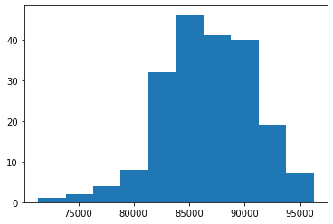

Enfriamiento de Boltzmann

### Parada y búsqueda exhaustiva

Sabiendo que los dos primeros métodos mejoran considerablemente la solución de nuestro problema lo lógico sería pensar que utilizarlas al mismo tiempo también produciría una mejora al algoritmo. Juntando ambos métodos pasamos a tener soluciones de 40-45k, que, si que es una mejora, pero no tanta en comparación a la mejora que se produce al añadir los métodos por primera vez.

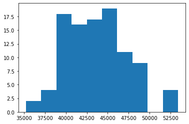

Parada y búsqueda de entorno